# Jupyter

## Installation

Pour construire note site, nous avez besoin d'une distribution Python. [Miniconda](https://conda.io/miniconda.html) est une solution légère permettant d'installer tous les packages nécessaires.

Une fois installer miniconda en ayant suivi les instructions, ouvrez un terminal sur Linux/Macos ou un anaconda prompt sur Windows.

### Environnement conda

```
git clone https://gitlab.math.unistra.fr/navaro/agrocampus
cd agrocampus
conda env create -n agrocampus
```

[documentation](https://conda.io/docs/using/envs.html).

L'environnement est créé a partir d'un fichier nommé `environment.yml` qui contient la liste des packages dont nous avons besoin.

### Activer l'environnement conda

Lorsque vous activer l'environement conda, votre configuration du terminal est modifiée et la version de python qui sera disponible sera celle ou tous nos packages seront installés.

```
$ conda activate agrocampus
(agrocampus) $ python
Python 3.6.2 (default, Jul 17 2017, 16:44:45)
[GCC 4.2.1 Compatible Apple LLVM 8.1.0 (clang-802.0.42)] on darwin
Type "help", "copyright", "credits" or "license" for more information.
>>> quit()
```

## Jupyter Notebook

- Le calepin Jupyter est un outil de rédaction qui permet de partager une analyse mathématique.
- Rassembler du code informatique, du texte, des images et des formules mathématiques dans un seul document.
- Le code informatique est modifiable et exécutable.
- Excellent support pour travailler et surtout pour partager.
- Jupyter comporte de nombreuses extensions et supporte [un nombre important de langages](https://github.com/jupyter/jupyter/wiki/Jupyter-kernels).
- Logiciel libre, ouvert et totalement gratuit qui fonctionne sur tous les systèmes d'exploitation existants.

Jupyter est un acronyme des 3 langages supportés à l'origine du projet: **JU**lia, **PYT**hon, et **R**

```
conda install -c conda-forge jupyter
```

## Raccoucis clavier

- Pour afficher les commandes disponibles: `Cmd + Shift + P`
- Exécuter une cellule
  - 'Cmd-Enter' exécute la cellule courante
  - 'Shift-Enter' exécute la cellule courante et passe à la suivante
  - 'Alt-Enter' exécute la cellule et crée une nouvelle en dessous.
- `Esc` permet de basculer en mode "commande" et vous pouvez naviguer dans le document avec les flèches de votre clavier. En mode "commande":
  - `A` permet d'insérer une nouvelle cellule **au dessus** de la cellule active
  - `B` permet d'insérer une nouvelle cellule **en dessous** de la cellule active
  - `M` bacule en mode texte (markdown), `Y` pour revenir au code
  - `D + D` en pressant deux fois ce caractère vous effacez la cellule courante
- "Shift-Ctrl-M" permet de couper une cellule en deux au niveau du curseur.

## Installation de packages Python dans Jupyter

### Avec conda

Pour installer `numpy` du canal *conda-forge*

```
%conda install -c conda-forge numpy
```

### Avec pip

```
%pip install numpy
```

## Documentation

- Shift + Tab donne accès à la documentation des fonctions

```python
dict
```

```
dict
```

Si vous passez la cellule suivante en *Code* et l'exécutez, la documentation apparaît dans le *pager*

??dict

## Graphique (en python)

la première ligne de la cellule suivante permet de tracer vos graphiques juste après l"éxécution de la céllule.

```python
%matplotlib inline
%config InlineBackend.figure_format = 'retina'
import matplotlib.pyplot as plt
import numpy as np
```

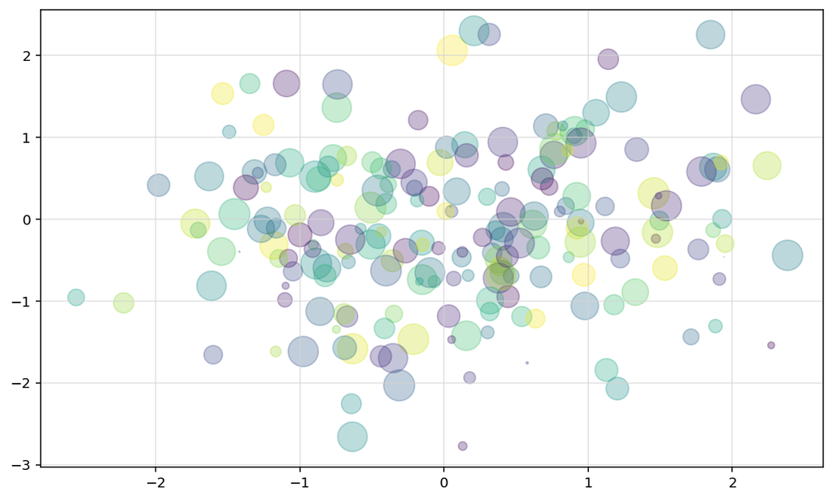

```python
plt.rcParams['figure.figsize'] = (10,6)
fig, ax = plt.subplots()
np.random.seed(0)
x, y = np.random.normal(size=(2, 200))
color, size = np.random.random((2, 200))

ax.scatter(x, y, c=color, s=500 * size, alpha=0.3)
ax.grid(color='lightgray', alpha=0.7)
```

## Les commandes magiques

```python
%lsmagic
```

```
Available line magics:
%alias  %alias_magic  %autoawait  %autocall  %automagic  %autosave  %bookmark  %cat  %cd  %clear  %colors  %conda  %config  %connect_info  %cp  %debug  %dhist  %dirs  %doctest_mode  %ed  %edit  %env  %gui  %hist  %history  %killbgscripts  %ldir  %less  %lf  %lk  %ll  %load  %load_ext  %loadpy  %logo…

Available cell magics:
%%!  %%HTML  %%SVG  %%bash  %%capture  %%debug  %%file  %%html  %%javascript  %%js  %%latex  %%markdown  %%perl  %%prun  %%pypy  %%python  %%python2  %%python3  %%ruby  %%script  %%sh  %%svg  %%sx  %%system  %%time  %%timeit  %%writefile

Automagic is ON, % prefix IS NOT needed for line magics.
```

```python
%ls
```

```
01-jupyter.ipynb    05-binder.ipynb          09-exemple-r.ipynb      images/
02-gitbasics.ipynb  06-jupytext.ipynb        10-github-action.ipynb  intro.md
03-markdown.ipynb   07-exemple-julia.ipynb   _config.yml             logo.png
04-docker.ipynb     08-exemple-python.ipynb  _toc.yml
```

```python
%%file sample.txt

write the cell content to the file sample.txt.
The file is created when you run this cell.
```

```
Writing sample.txt
```

```python
%cat sample.txt
```

```
write the cell content to the file sample.txt.
The file is created when you run this cell.
```

```python
%%file fibonacci.py

f1, f2 = 1, 1
for n in range(10):
    print(f1, end=',')
    f1, f2 = f2, f1+f2
```

```
Writing fibonacci.py
```

```python
%run fibonacci.py
```

```
1,1,2,3,5,8,13,21,34,55,
```

```python
# %load fibonacci.py

f1, f2 = 1, 1
for n in range(10):
    print(f1, end=',')
    f1, f2 = f2, f1+f2
```

```
1,1,2,3,5,8,13,21,34,55,
```

```python
%%time
f1, f2 = 1, 1
for n in range(10):
    print(f1, end=',')
    f1, f2 = f2, f1+f2
print()
```

```
1,1,2,3,5,8,13,21,34,55,
CPU times: user 359 µs, sys: 30 µs, total: 389 µs
Wall time: 239 µs
```

```python
%who int
```

```
f1	 f2	 n
```

```python
import numpy as np
%timeit np.random.normal(size=100)
```

```
8.91 µs ± 4.33 ns per loop (mean ± std. dev. of 7 runs, 100000 loops each)
```

```python
from time import sleep
def fibonacci(n):
    f1, f2 = 1, 1
    res = []
    for i in range(n):
        sleep(0.1)
        f1, f2 = f2, f1+f2
        res.append(f1)
    return res
```

```python
import IPython.core
IPython.core.page = print
```

```python
%prun -q -T prof.txt fibonacci(10)
```

```
*** Profile printout saved to text file 'prof.txt'.
```

```python
%cat prof.txt
```

```
         24 function calls in 1.002 seconds

   Ordered by: internal time

   ncalls  tottime  percall  cumtime  percall filename:lineno(function)
       10    1.002    0.100    1.002    0.100 {built-in method time.sleep}
        1    0.000    0.000    1.002    1.002 <ipython-input-14-ae0bde2ca159>:2(fibonacci)
        1    0.000    0.000    1.002    1.002 {built-in method builtins.exec}
       10    0.000    0.000    0.000    0.000 {method 'append' of 'list' objects}
        1    0.000    0.000    1.002    1.002 <string>:1(<module>)
        1    0.000    0.000    0.000    0.000 {method 'disable' of '_lsprof.Profiler' objects}
```

```python
%load_ext heat
```

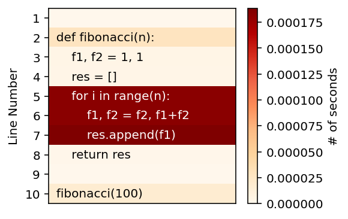

```python
%%heat

def fibonacci(n):
    f1, f2 = 1, 1
    res = []
    for i in range(n):
        f1, f2 = f2, f1+f2
        res.append(f1)
    return res

fibonacci(100)
```

```python
from tqdm.notebook import tqdm
from time import sleep

n = 10
res = [1]

for x in tqdm(range(2, n)):
    sleep(0.5)
    for i in range(2, x):
        if (x % i) == 0:
            break
        else:
            res.append(x)
            break

res
```

```
[1, 3, 5, 7, 9]
```

## Interactivité

```python
from ipywidgets import interact


@interact(x=True, y=1.0)
def g(x, y):
    return (x, y)
```

```python
@interact(tau=(0.01, 0.2, 0.01))
def f(tau):
    plt.figure(2)
    t = np.linspace(0, 1, num=1000)
    plt.plot(t, 1 - np.exp(-t/tau), t,  np.exp(-t/tau))
    plt.xlim(0, 1)
    plt.ylim(0, 1)
```

## Remarque importante

- Un calepin Jupyter n'est pas vraiment un programme Python
- Il s'agit d'une suite d'instructions exécutées dans un ordre particulier avec éventuellement des répétitions.
- Avant de partager un notebook, il est préférable d'aller dans l'onglet `Kernel` et cliquer sur `Restart & Run All` et vérifier que tout ce passe bien.

[figure not shown]

[@joelgrus](https://twitter.com/joelgrus/status/1290072502060740610?s=20)